# Cartagena de Indias Cruise Analysis

# Contextualization

The following analysis seeks to understand, in a general way, the cruise industry in the city of Cartagena. To do this, existing information is searched for on the web and this information is leveraged with online data capture techniques.

The port of Cartagena is managed by the “GRUPO PUERTO DE CARTAGENA” group, which is part of the Cartagena port company -infrastructure companies-, which was founded in 1993. Keep in mind that, in order to carry out a correct analysis of the port sector, cruise ships in the city, the context of the industry must be generally known.

The port of Cartagena is a maritime point that serves different types of vessels. In particular, there is information for the years 2021 to 2022. It should be noted that the effects of the COVID-19 pandemic have significantly affected the existing data, therefore, the predictive analyzes presented here are merely descriptive. Data are taken for exploratory analysis.

As of 2021, the port of Cartagena began a process of economic reactivation caused by the pandemic. The economic projections of the Port are shown below.

NOTE: Due coding index and syntaxis, some of the charts were not possible to get a full translation. They actually are possible to translate but it will delay the date to deliver the ouput.

## Port Comparison

The port of Cartagena de Indias in comparison with the other ports in the area, is the most important in terms of economic scope, operation and others.

| Year | 2000 | 2001 | 2002 | 2003 | 2004 | 2005 | 2006 | 2007 | 2008 | 2009 | 2010 | 2011 | 2012 | 2013 | 2014 | 2015 | 2016 | 2017 |
| --- | --- | --- | --- | --- | --- | --- | --- | --- | --- | --- | --- | --- | --- | --- | --- | --- | --- | --- |
| Cartagena de Indias | 147511 | 168855 | 85880 | 31063 | 38946 | 41542 | 42024 | 108892 | 206691 | 270257 | 286312 | 305932 | 251531 | 303915 | 309698 | 258992 | 291569 | 331335 |
| Santa Marta | 1633 | 235 | 208 | 742 | 737 | 1300 | 2550 | 13432 | 17424 | 13564 | 8684 | 6658 | 2768 | 2563 | 3988 | 10973 | 14168 | 14168 |
| San Andrés | 0 | 2208 | 8272 | 10804 | 9601 | 5237 | 6372 | 4566 | 4106 | 906 | 1053 | 563 | 104 | 216 | 521 | 2149 | 83 | 83 |
| Total | 149144 | 171298 | 94360 | 42609 | 49284 | 48115 | 50946 | 126890 | 228221 | 284727 | 296049 | 313403 | 254403 | 306694 | 314207 | 272114 | 305820 | 344624 |

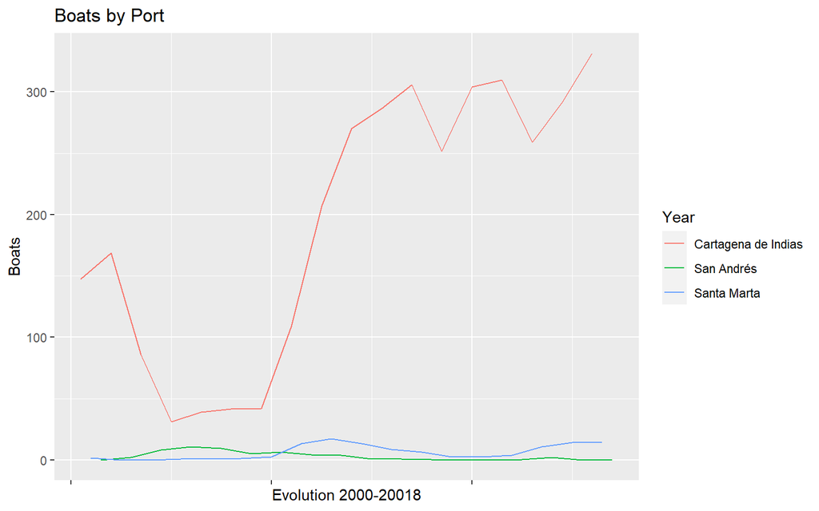

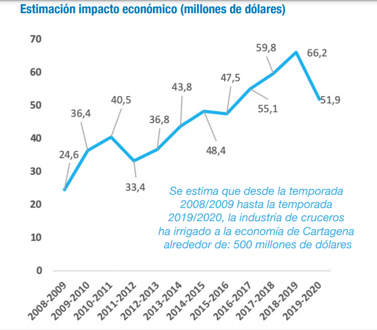

The previous graph shows the economic performance (in millions of US dollars) in the history of the data collected. Note that the values were increasing until before the pandemic. An exploratory graph of the history of tourism and trade data is attached.

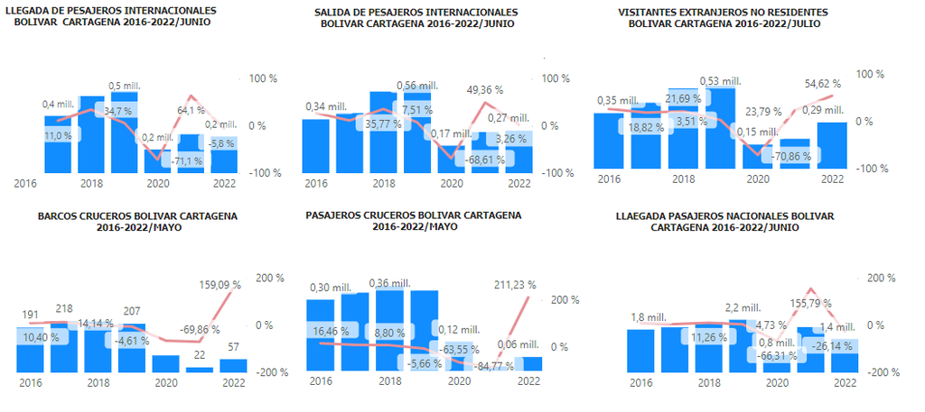

For each of the graphs, the line of % growth/decrease with respect to the previous year is shown in pink.

The bars represent the values associated with the measured variable.

# General analytics

A first indiscriminate analysis of the years is the total number of passengers by companies that provide cruise tourism services.

## Information by cruises

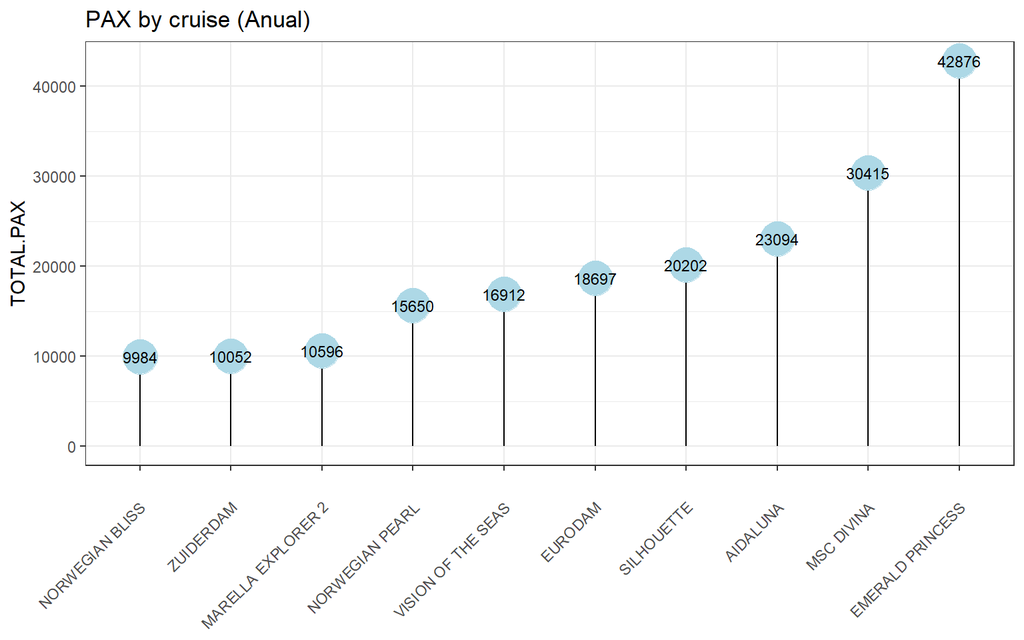

The graph above shows information on cruise ships that provide service in the port of Cartagena. You might think that there are three types of services. the first, given by companies that handle a smaller number of passengers annually (approximately ten thousand passengers). In this category are NORWEGIAN BLISS, ZUIDERDAM, MARELLA EXPLLORER 2.

Then there are the medium-sized ones, which could transport up to 20 thousand passengers annually.

And finally, the largest, which according to the data; annually they transport more than 20 thousand passengers, up to 40,000; the latter being the EMERALD PRINCESS.

## Total passengers per month

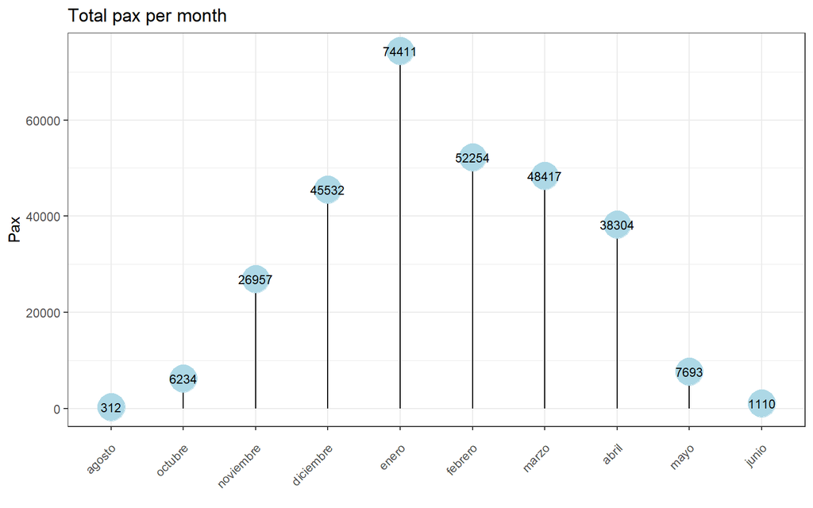

Similarly, we have the total number of passengers. Note that there are months where the total number of passengers increases. In this regard, keep in mind the cruise ticket sales cycles, that a reservation is usually made with a considerable margin of time when compared to airline services, for example.

## Expenses per passenger

The following table shows pertinent information regarding the average spend per person on cruises. This, without categorizing by year.

| PAX type | # of PAX | Daily expenses USD | Incoming aprox. USD |
| --- | --- | --- | --- |
| PAX | 424,734 | 122,43 | 52.000.183 |
| Crew | 158,932 | 70.01 | 11.126.829 |

## Number of landfalls per year

Landfall is defined as the action of a ship to reach port. For the port we have the following:

[figure not shown]

## About passengers

According to data obtained from Citur, to understand the behavior of cruise ships; data is also available about their size (Measurement of ‘Length’) and the number of passengers.

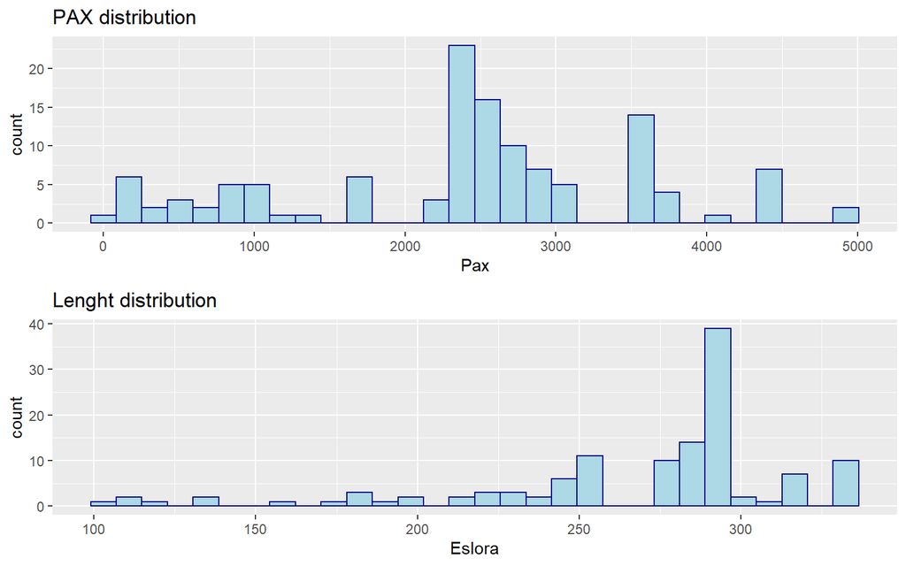

Given these data, there seem to be 3 categories. Notice that, in the charts, they are “split” into three different groups. a first group, which handles a smaller number of passengers (between 0 and 1000 passengers)

The next group, between 2000 passengers and less than 4 thousand.

The third group, more than 4 thousand passengers.

This analysis is consistent in relation to the distribution of the Length; where 3 large groups are also segregated. Small, medium and large lengths.

# Market analysis for 2021

There is a total number of ships registered in the port of Cartagena for the year 2021.

| Barcaza | Bongo | Cargueros | Fragata | Otras embarcaciones menores | Pesquero | Portacontenedores | Remolcador | Turismo | Roll on Roll of | Mixto | 2021 |
| --- | --- | --- | --- | --- | --- | --- | --- | --- | --- | --- | --- |
| 504 | 555 | 245 | 9 | 3 | 7 | 2003 | 181 | 22 | 53 | 4 | 3586 |

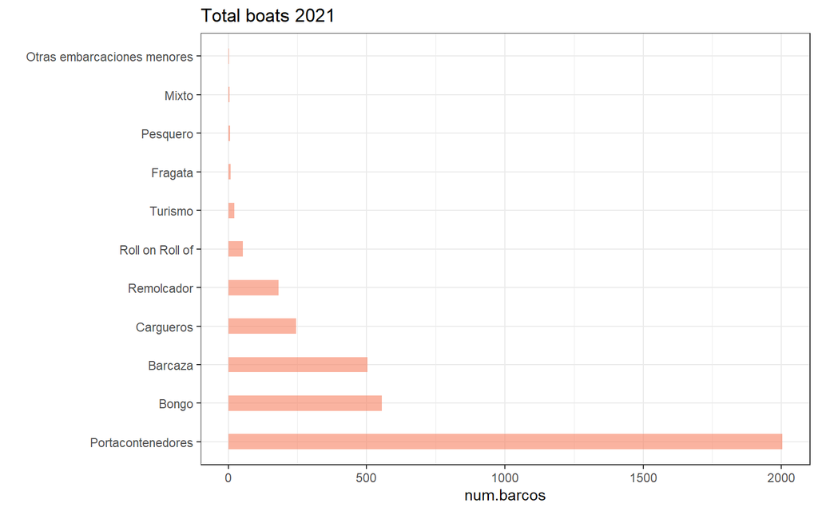

The total number of cruise ships (Tourism Category) for this year represents less than 1% of the total number of ships arriving at the port.

# Market analysis

For the year 2022, the following information is available up to May.

| Barcaza | Bongo | Cargueros | Pesquero | Portacontenedores | Remolcador | Roll on Roll of | Turismo | Cabotaje especial | Fragata | Mixto | Otras embarcaciones menores | 2022 |
| --- | --- | --- | --- | --- | --- | --- | --- | --- | --- | --- | --- | --- |
| 300 | 93 | 54 | 1 | 582 | 65 | 8 | 56 | 1 | 2 | 1 | 18 | 1181 |

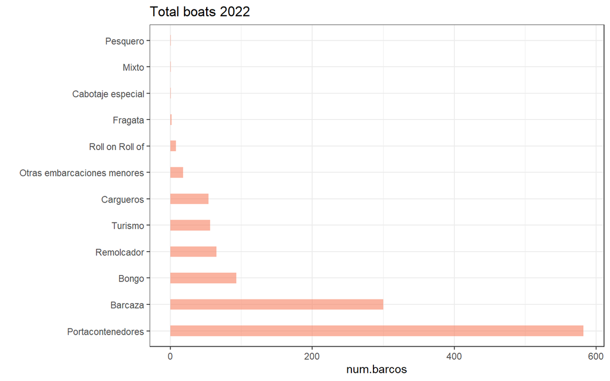

The general behavior of the type of vessels has not changed from one year to another. Note that for the year 2022 (only until May) there is a considerable increase in the number of ships that arrive. This is given the effect of COVID, since for the entire year 2021 there is a record of 22 tourist boats in the port; which contrasts with the total obtained until May 2022, a total of 56 ships.

# Average ticket price

To calculate the average price, a sample is made of the data from different web pages in which the information of the respective cruise ticket is extracted based on the category. Thus, you have to:

The following tables present the average value of a ticket based on the category. On cruises, there are several categories of tickets (rooms) to reserve. In this case, the most basic ticket offers a single room on the boat. The second category offers a room with a window, the third, a room with a balcony and finally the highest category is the suite. To carry out these calculations, a general sampling is carried out to understand the behavior of these prices. The first table provides the average values of these tickets. This is the value that tickets in these categories would be expected to take. The second table presents what are called “Confidence Intervals”; abbreviated as IC. The latter are used to give a general behavior of the variability. In a nutshell, the first line presents the minimum lower value that a ticket of a given category can take. The second line of the table shows the maximum value that the ticket can take.

|  | Standard | Standard_window | Balcony | Suite |
| --- | --- | --- | --- | --- |
| mean of x | 1401.143 | 1529.571 | 2273.143 | 3045.571 |

| IC Standardr | IC Standard_window | Balcony | IC Suite |
| --- | --- | --- | --- |
| 747.8197 | 747.0219 | 1352.976 | 1802.203 |
| 2054.4660 | 2312.1210 | 3193.310 | 4288.940 |

# Based on:

1. https://www.puertocartagena.com/sites/default/files/inline/infografia-reactivacion-cruceros-porticolive_compressed_1.pdf
2. https://www.puertocartagena.com/es/descargables-informativos
3. https://www.cruceros.co/pd-4-cartagena-de-indias
4. https://portucolombia.mincit.gov.co/tematicas/estadisticas-territoriales-de-turismo-1
5. https://deluxetravel.com.co/cotizar-cruceros/